# Indel Signature InsDel11

# InsDel11

**Note**

In the 89-type classification, InsDel16 and InsDel11 have a cosine similarity of 0.965, but as extracted from the 476-type classification, InsDel11 differs obviously from InsDel16, with insertion of single Cs next to isolated Cs (Cs with non-Cs on each side) and insertion of single Ts next to isolated Ts.

By contrast, InsDel_C has insertions of Cs between non-Cs and Gs, and insertion of Ts between non-Ts.

(corresponds to 83-type signature C_ID11 )

### Mutations by cancer type

Distribution of InsDel11 mutations across cancer types (mutations per megabase, log scale). Each dot represents a sample; red dashed line shows the median.

[figure not shown]

**Click to see sample counts by cancer type**

| Cancer Type | Samples with signature / Total |
| --- | --- |
| Breast | 2/953 (0.2%) |
| Biliary | 1/120 (0.8%) |
| Pancreas | 1/405 (0.2%) |
| Prostate | 1/689 (0.1%) |
| Skin | 1/432 (0.2%) |
| Bladder | 0/198 (0%) |
| Bone.SoftTissue | 0/286 (0%) |
| CNS | 0/293 (0%) |
| Colon | 0/652 (0%) |
| Esophagus | 0/246 (0%) |
| Head | 0/121 (0%) |
| Kidney | 0/306 (0%) |
| Liver | 0/378 (0%) |
| Lung | 0/575 (0%) |
| Lymphoid | 0/228 (0%) |
| Myeloid | 0/51 (0%) |
| Other | 0/353 (0%) |
| Ovary | 0/264 (0%) |
| Stomach | 0/112 (0%) |
| Thymus | 0/54 (0%) |
| Uterus | 0/122 (0%) |

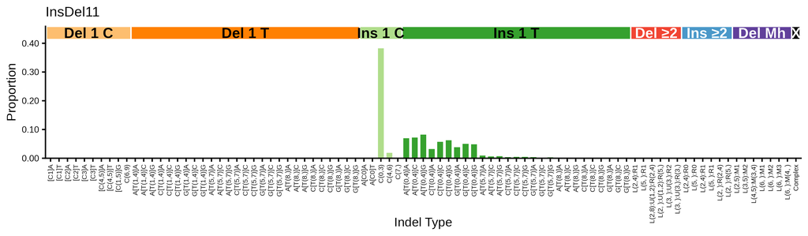

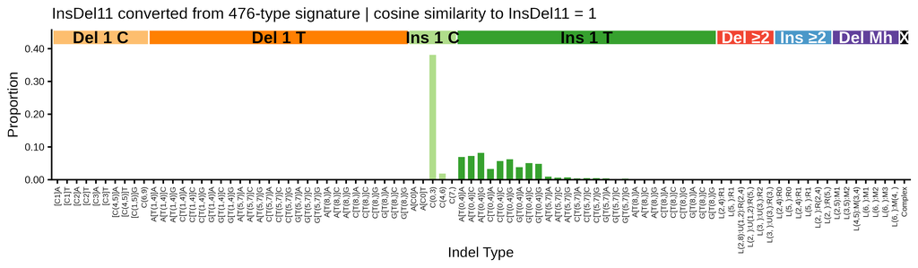

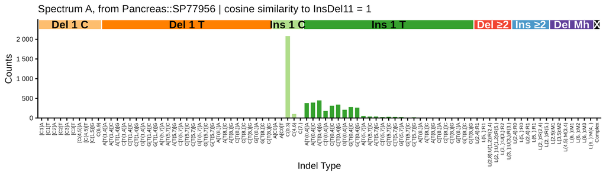

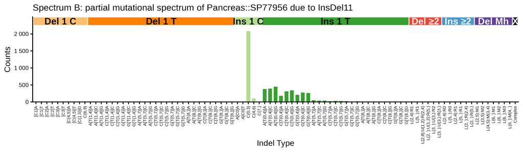

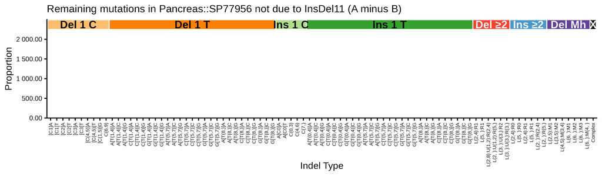

## 476-type representations corresponding to InsDel11

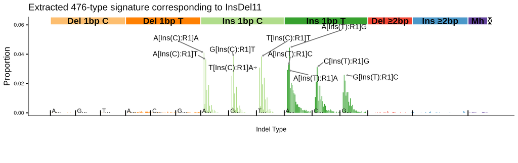

476-type spectrum of the supporting tumor Pancreas::SP77956; cosine similarity to the extracted 476-type signature is 1

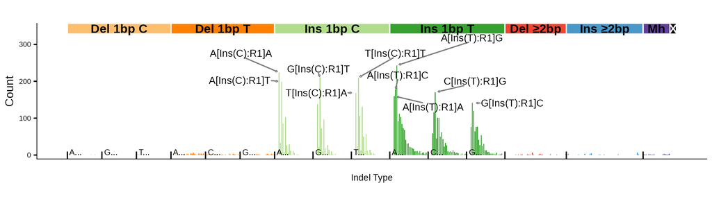

## 83-type signature corresponding to InsDel11 ( C_ID11 )

**Click here to show 83-type plots**

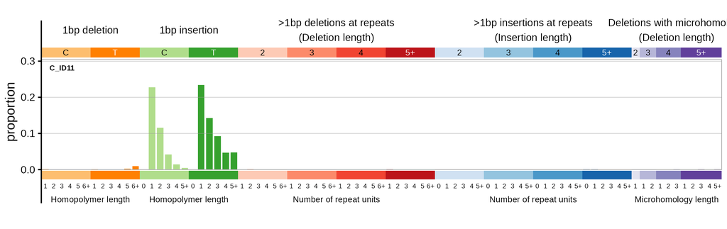

83-type signature converted from 476-type signature corresponding to InsDel11 | cosine similarity to C_ID11: 0.9998

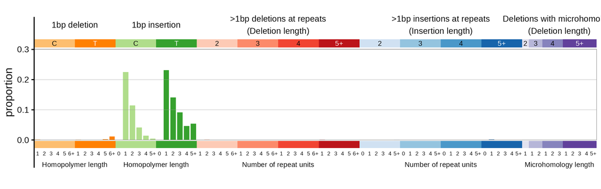

83-type spectrum of the supporting tumor Pancreas::SP77956 | cosine similarly to C_ID11: 0.9998

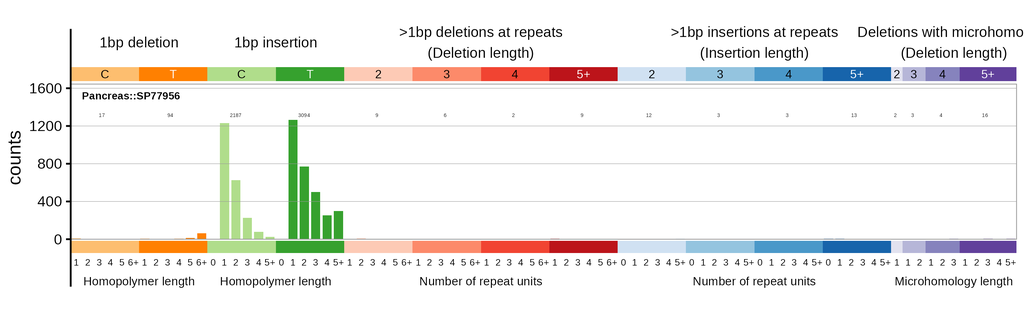

### Similar COSMIC signatures

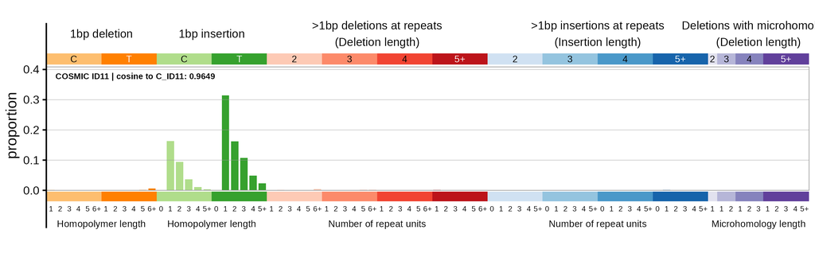

### Similar signatures from Jin et al. 2024

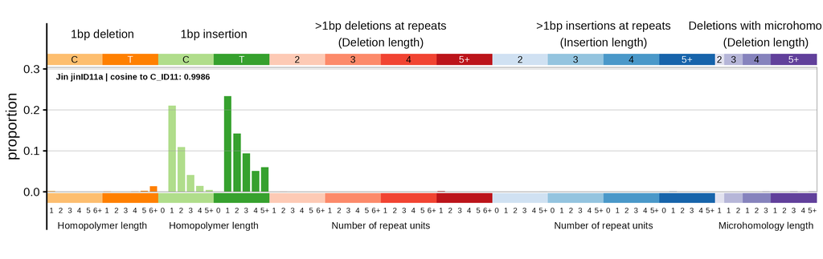